# RMedlineFunctions Examples ‘librarian’

This is a first attempt at building an example of RMedlineFunctions (https://github.com/fdsayre/RMedlineFunctions) using an RNoteBook to display some results.

A shorter example looking at ‘librarian[ti]’ is in the works.

Load functions and libraries

```r
source("RMedlineFunctions.R")
library(RISmed)
library(ggplot2)
library(dplyr)
```

Set query (can be anything you would search in pubmed.gov) retrieve medline data file

the first variable sets the first year you want results from (2000), the second the last year (2016), and the third the maximum number of results to return.

The turn that medline data file into a data frame with most article metadata (but not all!)

```r
query = 'librarian'
data <- RetrieveArticleData(query,2000,2016,30000)
article_metadata <- RetrieveMostArticleMetadata(data)
```

Let’s take a quick look at how pubmed translated that query

```r
Query(data)
```

```
[1] "(\"librarians\"[MeSH Terms] OR \"librarians\"[All Fields] OR \"librarian\"[All Fields]) AND 2000[EDAT] : 2016[EDAT]"
```

Create a basic bar chart shorting publication frequency by year from article metadata file (must contain at least a Year variable)

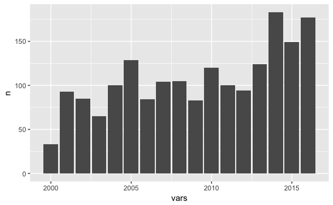

```r
ArticlesFreqYear(article_metadata)
```

Plot article status using medline data file

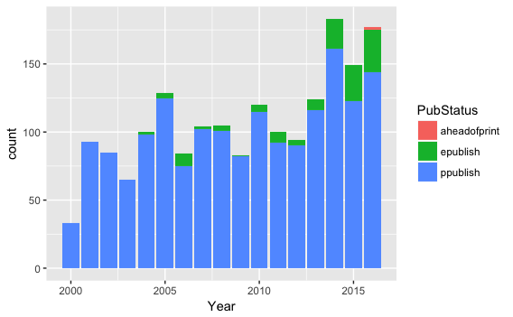

```r
PMStatusByYearPlot(data)
```

Get data on number of times each article has been cited and add that data to an existing article metadata file.

WARNING: CITATION DATA TAKES A LONG TIME TO COLLECT

variables for function: x = medline data file y = article metadata file that has PMIDs

```r
article_metadata_citations <- GetCitationData(data, article_metadata)
```

Plot citations for each paper as a scatterplot (each dot is independent)

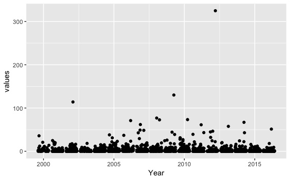

```r
PlotCitations(article_metadata_citations)
```

Bar graph of culumative citations by year This is really the total number of citations, so not incredibly useful

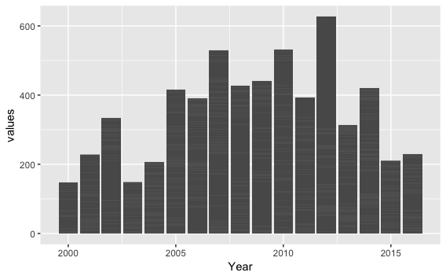

```r
PlotCitationsBar(article_metadata_citations)
```